# Machine Learning: Mathematical Theory and Applications

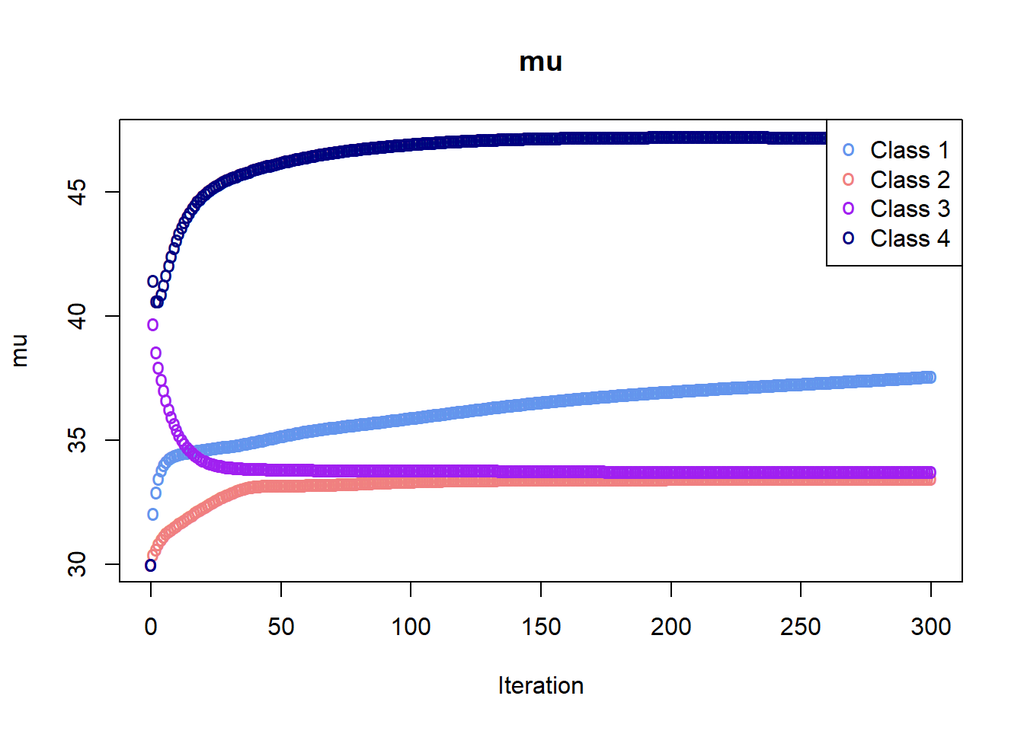

```r
matplot(0:n_iter, rbind(mu_start, EM_result_4$mu_all), main = 'mu', pch = c("o", "o", 'o','o'), col = c("cornflowerblue", "lightcoral", 'purple', 'navy'), xlab = "Iteration", ylab = "mu")
legend("topright", legend = c("Class 1", "Class 2", 'Class 3', 'Class 4'), col = c("cornflowerblue", "lightcoral", 'purple', 'navy'), pch = c("o", "o",'o', 'o'))
```

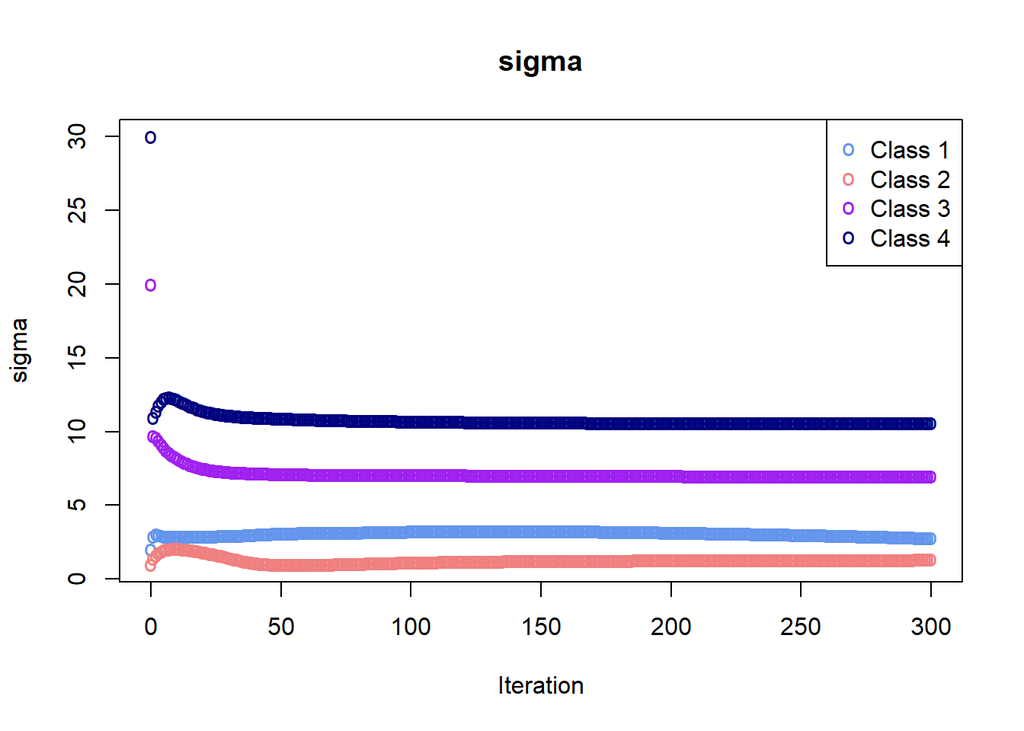

```r
matplot(0:n_iter, rbind(sigma_start, EM_result_4$sigma_all), main = 'sigma', pch = c("o", "o", 'o', 'o'), col = c("cornflowerblue", "lightcoral", 'purple', 'navy'), xlab = "Iteration", ylab = "sigma")
legend("topright", legend = c("Class 1", "Class 2", 'Class 3', 'Class 4'), col = c("cornflowerblue", "lightcoral", 'purple', 'navy'), pch = c("o", "o", 'o', 'o'))
```

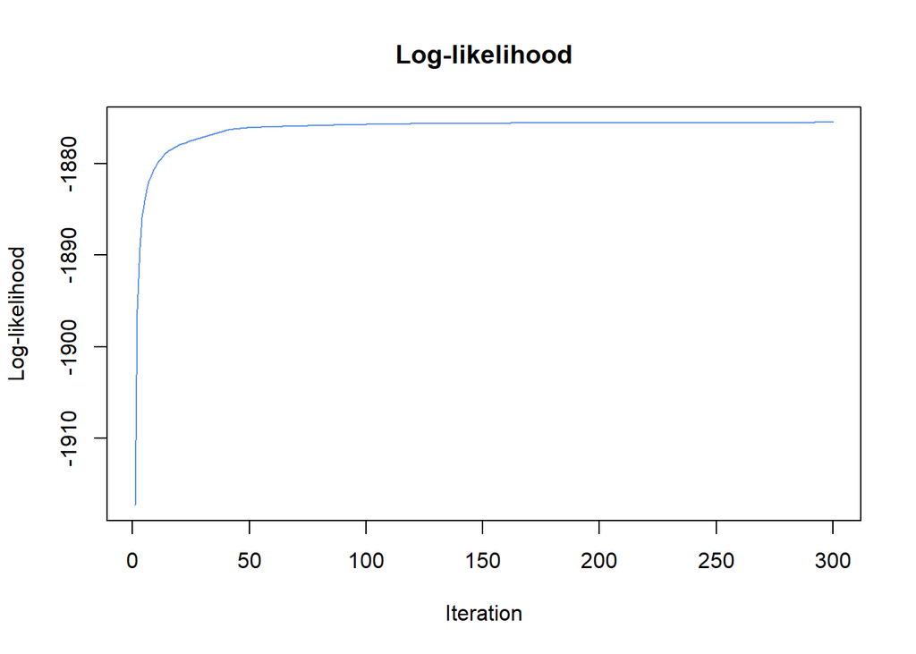

```r
par(mfrow = c(1, 1))
# Inspect convergence
plot(EM_result_4$log_like_all, main = 'Log-likelihood', type = "l", col = "cornflowerblue", xlab = "Iteration", ylab = "Log-likelihood")
```

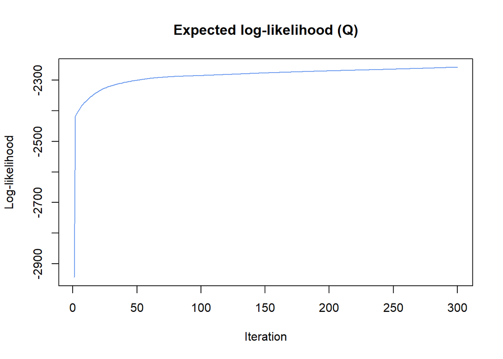

```r
plot(EM_result_4$Q_all, main = 'Expected log-likelihood (Q)', type = "l", col = "cornflowerblue", xlab = "Iteration", ylab = "Log-likelihood")
```

```r
print("Estimated parameters (pi, mu, and sigma)")
```

```
[1] "Estimated parameters (pi, mu, and sigma)"
```

```r
print(EM_result_4$pi_hat)
```

```
[1] 0.07335195 0.10429090 0.57564344 0.24671371
```

```r
print(EM_result_4$mu_hat)
```

```
[1] 37.58447 33.47183 33.74994 47.21059
```

```r
print(EM_result_4$sigma_hat)
```

```
[1]  2.786338  1.327430  6.992585 10.605984
```

#### 💪 Problem 4.5

Plot $p(x)$ (using the estimates from your EM algorithm) for the two models in Problem 4.4 in the same figure as a (normalised) histogram obtained with the `hist()` with the argument `breaks=30`. Which of the two models seem visually better for modelling the fish’ lengths?

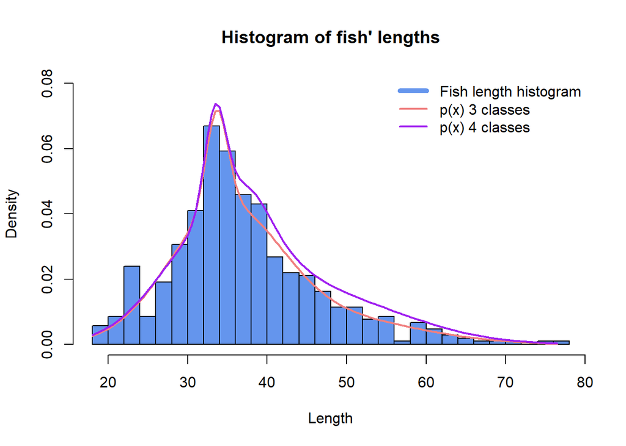

```r
y_fish_3 = (1 / sqrt(2 * pi * EM_result_3$sigma_hat[1]^2)) * exp(- (x_fish - EM_result_3$mu_hat[1])^2 / (2 * EM_result_3$sigma_hat[1]^2)) * EM_result_3$pi_hat[1] +(1 / sqrt(2 * pi * EM_result_3$sigma_hat[2]^2)) * exp(- (x_fish - EM_result_3$mu_hat[2])^2 / (2 * EM_result_3$sigma_hat[2]^2)) * EM_result_3$pi_hat[2] + (1 / sqrt(2 * pi * EM_result_3$sigma_hat[3]^2)) * exp(- (x_fish - EM_result_3$mu_hat[3])^2 / (2 * EM_result_3$sigma_hat[3]^2)) * EM_result_3$pi_hat[3]

y_fish_4 = (1 / sqrt(2 * pi * EM_result_4$sigma_hat[1]^2)) * exp(- (x_fish - EM_result_4$mu_hat[1])^2 / (2 * EM_result_4$sigma_hat[1]^2)) * EM_result_4$pi_hat[1] +(1 / sqrt(2 * pi * EM_result_4$sigma_hat[2]^2)) * exp(- (x_fish - EM_result_4$mu_hat[2])^2 / (2 * EM_result_4$sigma_hat[2]^2)) * EM_result_4$pi_hat[2] + (1 / sqrt(2 * pi * EM_result_4$sigma_hat[3]^2)) * exp(- (x_fish - EM_result_4$mu_hat[3])^2 / (2 * EM_result_4$sigma_hat[3]^2)) * EM_result_4$pi_hat[3] + (1 / sqrt(2 * pi * EM_result_4$sigma_hat[3]^2)) * exp(- (x_fish - EM_result_4$mu_hat[4])^2 / (2 * EM_result_4$sigma_hat[4]^2)) * EM_result_4$pi_hat[4]


hist(x_fish, col = "cornflowerblue", main = "Histogram of fish' lengths", prob = TRUE, xlab = "Length", breaks = 30, ylim = c(0,0.08))
lines(x_fish, y_fish_3, col = "lightcoral", lwd = 2)
lines(x_fish, y_fish_4, col = "purple", lwd = 2)
legend("topright",
       legend = c("Fish length histogram", "p(x) 3 classes", 'p(x) 4 classes'),
       col = c("cornflowerblue", "lightcoral", 'purple'),
       lwd = c(5, 2, 2), bty = "n")
```

**Note**

**Answers:**

Visually, the model with four classes appears to provide a slightly better fit. However, neither the three-class nor the four-class density lines represent the number of classes. This suggests that neither model adequately fits the data.

To validate this observation, I also estimated the models using both `normalmixEM` and the custom `EM_GMM_M` function with various starting values. The two methods consistently converged to far different parameter estimates unless `EM_GMM_M` was forced to start from `normalmixEM`’s estimates. Furthermore, even when using `normalmixEM`, the resulting density curves do not align well with the histogram. The plots suggest that multiple density peaks exist, however, the distribution are not clearly distinct. The curves overlap considerably, suggesting that the models can be simplified.

```r
#trial with the normalmixEM function 3-class fish data
set.seed(0)
mix_result_3 = normalmixEM(x_fish, k = 3, maxit = 5000)
```

```
number of iterations= 980
```

```r
# Print results
summary(mix_result_3)
```

```
summary of normalmixEM object:
          comp 1    comp 2     comp 3
lambda  0.115631  0.844252  0.0401167
mu     53.685594 34.485391 49.8806652
sigma   9.325183  6.444432  3.4330592
loglik at estimate:  -1881.427
```

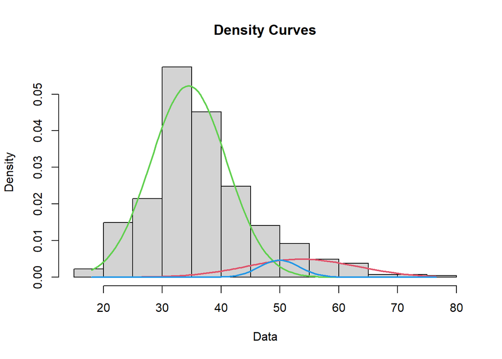

```r
plot(mix_result_3, which = 2)
```

```r
#trial with the normalmixEM function 4-class fish data
set.seed(0)
mix_result_4 = normalmixEM(x_fish, k = 4, maxit = 5000)
```

```
number of iterations= 2858
```

```r
# Print results
summary(mix_result_4)
```

```
summary of normalmixEM object:
          comp 1     comp 2    comp 3      comp 4
lambda  0.132754  0.0997757  0.763929  0.00354095
mu     52.713376 33.6703627 34.947554 75.76651560
sigma   7.818233  1.3355943  7.150438  0.74981820
loglik at estimate:  -1874.05
```

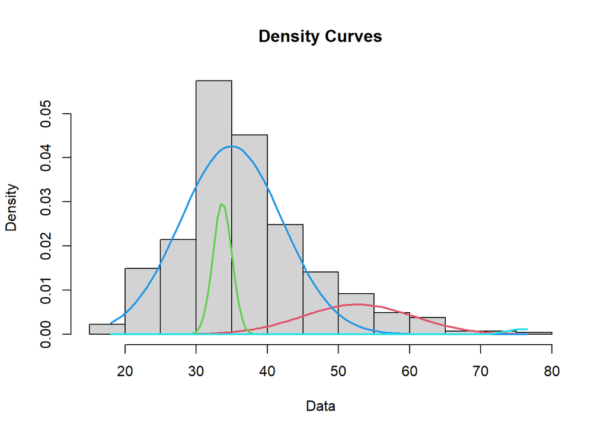

```r
plot(mix_result_4, which = 2)
```

When the features are multivariate, such as in the example with the ASB stock above, the code for the EM algorithm requires some modification. However, the understanding and application of unsupervised Gaussian mixtures is the same as in the univariate case. The next problem uses a package to estimate an unsupervised (multivariate) Gaussian mixture model for the ASB stock application.

#### 💪 Problem 4.6

Use the function `mvnormalmixEM()` from the `mixtools` package to estimate an unsupervised (multivariate) Gaussian mixture model with $M=2$ classes to the ASB stock example with feature vector $\mathbf{x}=(x_1,x_2)^\top$, with $x_1=\text{Close}$ and $x_2=\text{log(Volume)}$. Use all observations as training data. Plot a scatter plot with the predicted classes for the training data (use different colors to represent the different classes).

```r
x_1 = asb$Close
x_2 = log(asb$Volume)
x_asb = cbind(x_1, x_2)
set.seed(0)
mix_result_asb = mvnormalmixEM(x_asb, k=2)
```

```
number of iterations= 11
```

```r
summary(mix_result_asb)
```

```
summary of mvnormalmixEM object:
          comp 1    comp 2
lambda  0.652395  0.347605
mu1    17.933362 24.106904
mu2    13.686076 13.652133
loglik at estimate:  -1907.151
```

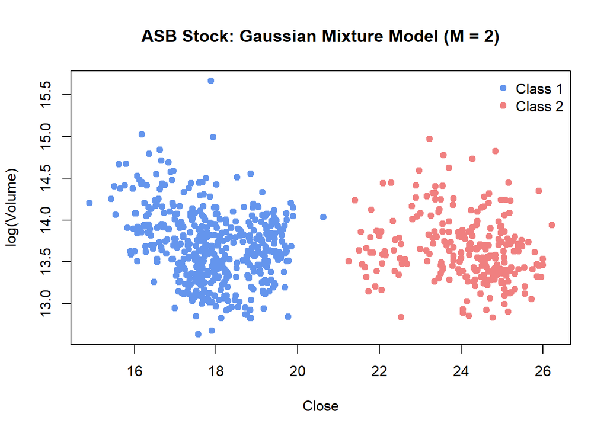

```r
pred_class <- apply(mix_result_asb$posterior, 1, which.max)

# Define custom colors for each class
colors <- c("cornflowerblue", "lightcoral")

# Plot scatter with predicted classes
plot(x_asb,
     col = colors[pred_class],
     pch = 19,  # filled circles look better
     xlab = "Close",
     ylab = "log(Volume)",
     main = "ASB Stock: Gaussian Mixture Model (M = 2)")

# Add legend
legend("topright",
       legend = paste("Class", 1:2),
       col = colors,
       pch = 19,
       bty = "n")
```

## 5. Semi supervised learning (3 marks)

In Problems 1 and 2 we assumed that all labels were observed, whereas none of them were observed in Problems 3 and 4. Another scenario is that labels are partially observed, i.e. we know the labels for a set of observations only. Statistical learning and modelling under this assumption is referred to as semi supervised learning.

One of the most common applications of semi supervised learning is in missing data problems. In this problem, we study the capability of semi supervised learning to learn parameters accurately compared to a fully supervised learning algorithm. Moreover, we compare the accuracy of predictions that account for missing labels to those who ignore the observations with missing labels.

We consider the problem of classifying penguins into species. The data are stored in the file `palmer_penguins_missing.Rdata`, which can be downloaded from the Canvas page of the course[^3]. The dataset contains a set of features for 265 penguins of two different species, Adelie and Gentoo. The species variable is missing for 49 of the penguins. The following code reads in the data and plots the classes and missing labels in a two-dimensional feature space consisting of the penguin’s flipper length (length of the wing) and body mass.

```r
load("C:/Users/26038024/Downloads/palmer_penguins_missing.RData")
# Get indices to the classes
ind_gentoo <- (palmer_penguins_missing$species == "Gentoo")
ind_adelie <- (palmer_penguins_missing$species == "Adelie")
ind_missing <- is.na(palmer_penguins_missing$species)
print(length(ind_gentoo))
```

```
[1] 265
```

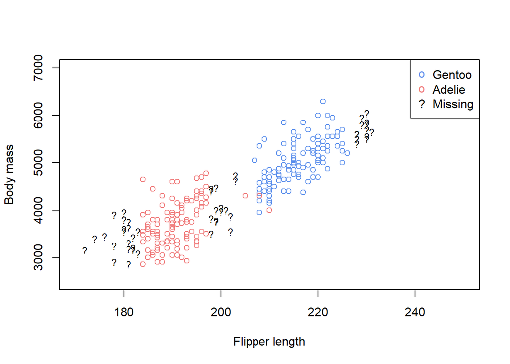

```r
x1 <- palmer_penguins_missing$flipper_length_mm
x2 <- palmer_penguins_missing$body_mass_g
plot(x1[ind_gentoo], x2[ind_gentoo], type = "p", col = "cornflowerblue", xlim = c(170, 250), ylim = c(2500, 7000), xlab = "Flipper length", ylab = "Body mass")
lines(x1[ind_adelie], x2[ind_adelie], type = "p", col = "lightcoral")
lines(x1[ind_missing], x2[ind_missing], type = "p", pch = "?", cex = 0.8, col = "black")
legend("topright", legend = c("Gentoo", "Adelie", "Missing"), col = c("cornflowerblue", "lightcoral", "black"), pch = c("o", "o", "?"))
```

For simplicity we use a single feature, the flipper length, in the problems below.

#### 💪 Problem 5.1

Estimate a (fully) supervised Gaussian mixture model for the penguin data with species as labels and a single feature flipper length. Use separate means and variances for the classes.

**Tip**

A supervised Gaussian mixture assumes all labels are known. We can remove the observations with missing labels by creating a new data frame with no missing values as `df_no_missing<-na.omit(palmer_penguins_missing)`.

```r
df_no_missing <- na.omit(palmer_penguins_missing)
ind_gentoo <- df_no_missing$species == "Gentoo"
ind_adelie <- df_no_missing$species == "Adelie"
x_no_missing <- df_no_missing$flipper_length_mm
```

```r
mean_gentoo = mean(x_no_missing[ind_gentoo])
mean_adelie = mean(x_no_missing[ind_adelie])
print(mean_gentoo)
```

```
[1] 215.7404
```

```r
print(mean_adelie)
```

```
[1] 190.7679
```

```r
sd_gentoo = sd(x_no_missing[ind_gentoo])
sd_adelie = sd(x_no_missing[ind_adelie])
print(sd_gentoo)
```

```
[1] 5.035785
```

```r
print(sd_adelie)
```

```
[1] 4.690381
```

```r
prior_gentoo <- sum(ind_gentoo) / nrow(df_no_missing)
prior_adelie <- sum(ind_adelie) / nrow(df_no_missing)
print(prior_gentoo)
```

```
[1] 0.4814815
```

```r
print(prior_adelie)
```

```
[1] 0.5185185
```

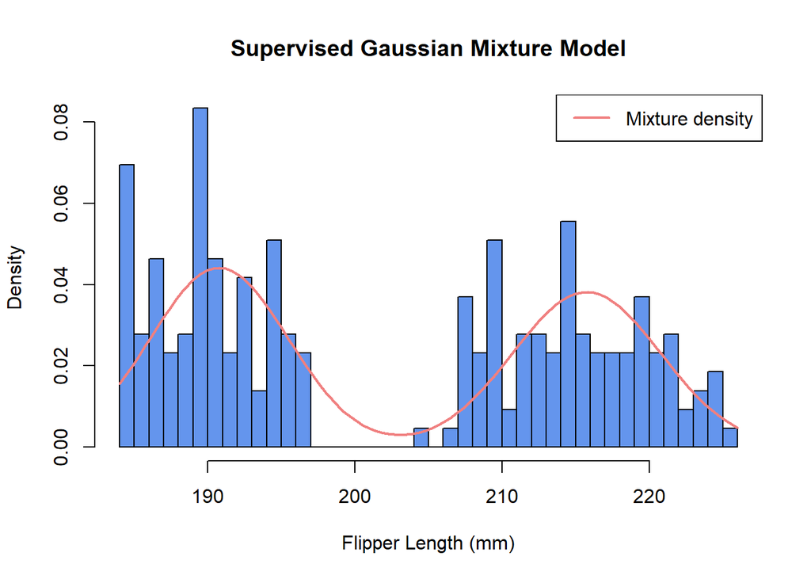

```r
# Define grid over x-axis range
x_grid <- seq(min(x_no_missing), max(x_no_missing), length.out = 100)

# Compute Gaussian mixture density
density_gentoo <- prior_gentoo * dnorm(x_grid, mean = mean_gentoo, sd = sd_gentoo)
density_adelie <- prior_adelie * dnorm(x_grid, mean = mean_adelie, sd = sd_adelie)
density_mixture <- density_gentoo + density_adelie
# Plot histogram
hist(x_no_missing,
     breaks = 30,
     probability = TRUE,
     col = "cornflowerblue",
     main = "Supervised Gaussian Mixture Model",
     xlab = "Flipper Length (mm)",
     border = "black")

# Add component densities
lines(x_grid, density_mixture, col = 'lightcoral', lwd = 2)

# Add legend
legend("topright",
       legend = 'Mixture density',
       col = c('lightcoral'),
       lwd = 2)
```

#### 💪 Problem 5.2

Estimate a semi supervised Gaussian mixture model for the penguin data with species as labels and a single feature flipper length. Compare the parameter estimates to those in Problem 5.1. Comment on the result.

**Tip**

As discussed in the lecture, semi supervised learning can be cast as a special version of the EM algorithm. Adapt the `EM_GMM_M2` function to take an extra argument that contains a vector of labels (with `NA` for unknown labels) and construct the weights accordingly. Note that the log-likelihood of the non-missing observations is monitored (for convergence) in semi supervised learning. This requires modifying `log_like_all`.

```r
EM_GMM_semi <- function(x, mu_start, sigma_start, pis_start, label_start, n_iter) {
  # label_start is a vector of all the labels including NA
  # Estimates the parameters in an unsupervised Gaussian mixture model with M = 2 classes.
  # Runs the EM algorithm for n_iter iterations. x is assumed univariate.
  # mu_start, sigma_start, pis_start are starting values.
  stopifnot(sum(pis_start) == 1)
  # Quantities to save
  pis_all <-  matrix(NA, nrow = n_iter, ncol = 2)
  mu_all <- matrix(NA, nrow = n_iter, ncol = 2)
  sigma_all <- matrix(NA, nrow = n_iter, ncol = 2)
  Q_all <- rep(NA, n_iter)
  log_like_all <- rep(NA, n_iter)

  # Initialise
  mu <- mu_start
  sigma <- sigma_start
  pis <- pis_start
  n <- length(x)
  W <- matrix(0, nrow = n, ncol = 2) # Unnormalised weights for each observation
  log_pdf_class <- matrix(0, nrow = n, ncol = 2) # The log-likelihood of the two classes for each obs. To compute Q.
  for(j in 1:n_iter){
    # Start EM steps
    # E-step: Compute the expected log-likelihood Q
    for(m in 1:2){
      # The log-density for each class
      log_pdf_class[, m] <- dnorm(x, mean = mu[m], sd = sigma[m], log = TRUE) + log(pis[m])
      # Unnormalised weights
      W[, m] <- pis[m]*dnorm(x, mean = mu[m], sd = sigma[m])
    }
    w <- W/rowSums(W) # Normalise weights

    # Overwrite the weights for labeled data, 1 for Gentoo and 0 for Adelie
    w[!is.na(label_start), 1] <- ifelse(label_start[!is.na(label_start)] == "Gentoo", 1, 0)
    w[!is.na(label_start), 2] <- ifelse(label_start[!is.na(label_start)] == "Gentoo", 0, 1)

    n_hat <- colSums(w) # Expected number of obs per class
    Q <- sum(rowSums(w*log_pdf_class)) # Expected log-likelihood

    # M-step: Maximise Q. Closed form analytical solution in Gaussian mixture models
    for(m in 1:2){
      pis[m] <- n_hat[m]/n
      mu[m] <- 1/n_hat[m]*sum(w[, m]*x)
      sigma[m] <- sqrt(1/n_hat[m]*sum(w[, m]*(x - mu[m])^2))
    }
    # End EM steps. Save estimates, Q, and log-likelihood
    pis_all[j, ] <- pis
    mu_all[j, ] <- mu
    sigma_all[j, ] <- sigma
    Q_all[j] <- Q
    # Compute log-likelihood at current parameter values
    for(m in 1:2){
      # Unnormalised weights
      W[, m] <- pis[m]*dnorm(x, mean = mu[m], sd = sigma[m])
    }
    # calculate log_like_all for NA data only
    log_like_all[j] <- sum(log(rowSums(W[is.na(label_start), ,drop = FALSE])))

  } # End EM iterations
  # Return everything as a list
  return(list(pi_hat = pis, mu_hat = mu, sigma_hat = sigma,
              weights = W/rowSums(W), pis_all = pis_all,
              mu_all = mu_all, sigma_all = sigma_all, Q_all = Q_all,
              log_like_all = log_like_all))
}
```

```r
label_start <- palmer_penguins_missing$species
# Starting values from labeled subset
mu_start <- c(mean_gentoo, mean_adelie)
sigma_start <- c(sd_gentoo, sd_adelie)
pis_start <- c(prior_gentoo, prior_adelie)
n_iter = 30
# Run semi-supervised EM
EM_result_semi <- EM_GMM_semi(
  x = palmer_penguins_missing$flipper_length_mm,
  mu_start = mu_start,
  sigma_start = sigma_start,
  pis_start = pis_start,
  label_start = label_start,
  n_iter = n_iter
)
```

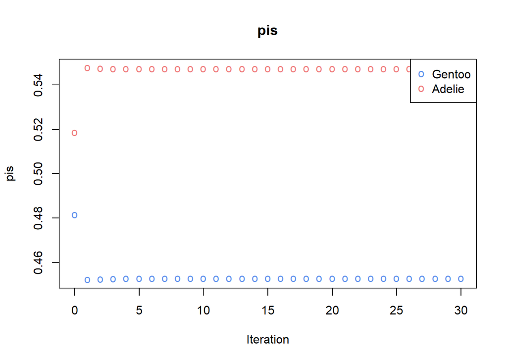

```r
matplot(0:n_iter, rbind(pis_start, EM_result_semi$pis_all), main = 'pis', pch = c("o", "o"), col = c("cornflowerblue", "lightcoral"), xlab = "Iteration", ylab = "pis")
legend("topright", legend = c("Gentoo", "Adelie"), col = c("cornflowerblue", "lightcoral"), pch = c("o", "o"))
```

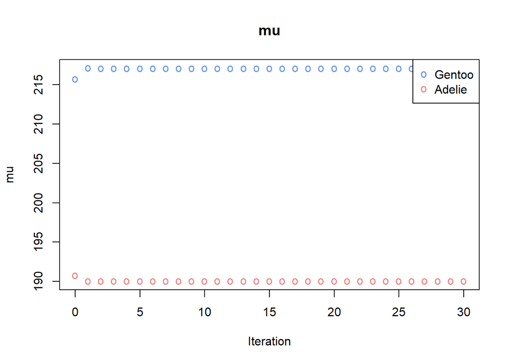

```r
matplot(0:n_iter, rbind(mu_start, EM_result_semi$mu_all), main = 'mu', pch = c("o", "o"), col = c("cornflowerblue", "lightcoral"), xlab = "Iteration", ylab = "mu")
legend("topright", legend = c("Gentoo", "Adelie"), col = c("cornflowerblue", "lightcoral"), pch = c("o", "o"))
```

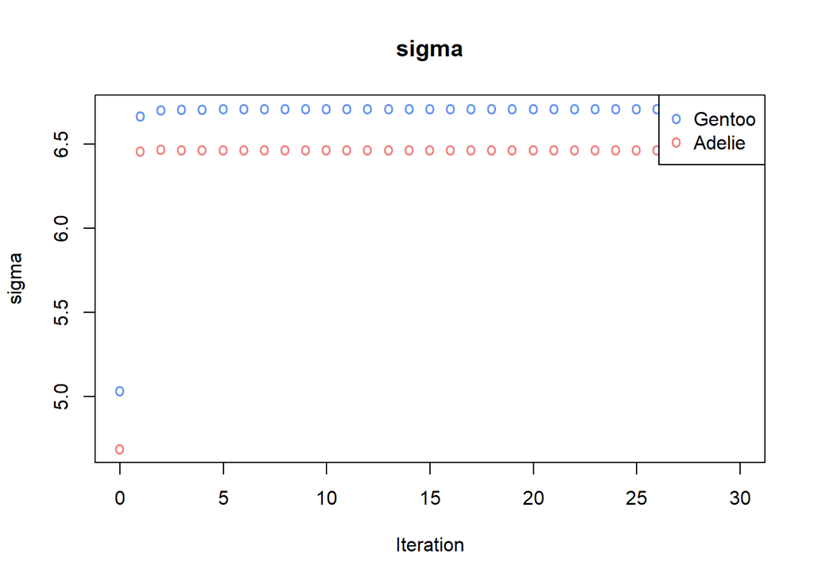

```r
matplot(0:n_iter, rbind(sigma_start, EM_result_semi$sigma_all), main = 'sigma', pch = c("o", "o"), col = c("cornflowerblue", "lightcoral"), xlab = "Iteration", ylab = "sigma")
legend("topright", legend = c("Gentoo", "Adelie"), col = c("cornflowerblue", "lightcoral"), pch = c("o", "o"))
```

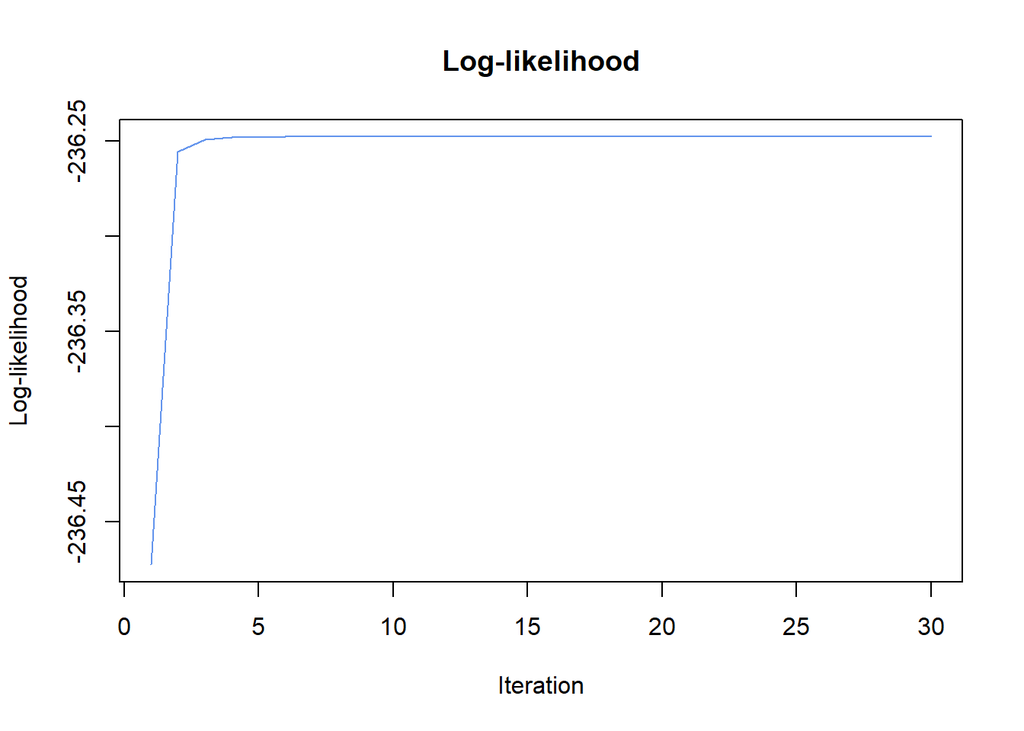

```r
par(mfrow = c(1, 1))
# Inspect convergence
plot(EM_result_semi$log_like_all, main = 'Log-likelihood', type = "l", col = "cornflowerblue", xlab = "Iteration", ylab = "Log-likelihood")
```

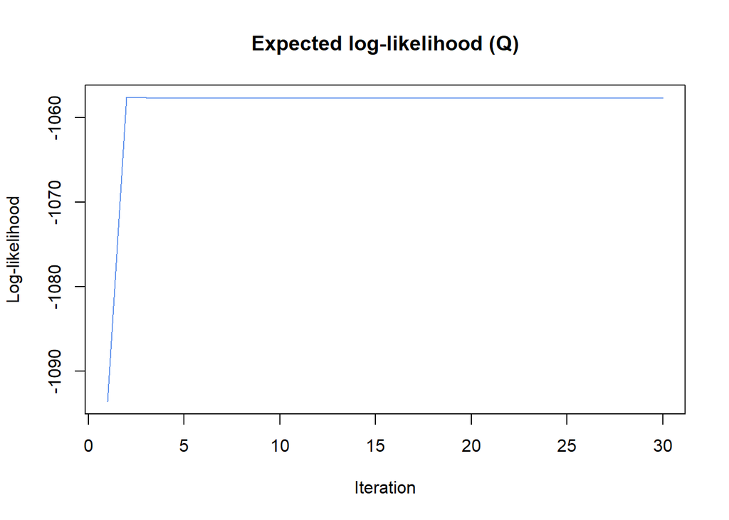

```r
plot(EM_result_semi$Q_all, main = 'Expected log-likelihood (Q)', type = "l", col = "cornflowerblue", xlab = "Iteration", ylab = "Log-likelihood")
```

```r
print("Estimated parameters (pi, mu, and sigma)")
```

```
[1] "Estimated parameters (pi, mu, and sigma)"
```

```r
print(EM_result_semi$pi_hat)
```

```
[1] 0.4527483 0.5472517
```

```r
print(EM_result_semi$mu_hat)
```

```
[1] 217.0959 190.0351
```

```r
print(EM_result_semi$sigma_hat)
```

```
[1] 6.710132 6.468163
```

**Note**

**Answers:**

The results from `EM_GMM_semi` differ slightly from those of the supervised GMM. This difference likely arises because `EM_GMM_semi` incorporates unlabeled data into the estimation process, which slightly shifts the parameter estimates. As a result, the semi-supervised GMM may better capture the overall data distribution but will no longer perfectly align with the supervised model trained solely on labeled observations.

```
supervised [1] 0.4814815 0.5185185 [1] 215.7404 190.7679 [1] 5.035785 4.690381
semi       [1] 0.4527483 0.5472517 [1] 217.0959 190.0351 [1] 6.710132 6.468163
```

#### 💪 Problem 5.3

The dataset `palmer_penguins.Rdata`, which can be downloaded from the Canvas page of the course, contains the true values for the labels that are missing in `palmer_penguins_missing.Rdata`. Compute the accuracy of the predictions for these observations using your semi supervised Gaussian mixture model in Problem 5.2. Compare that to the classification obtained via your supervised Gaussian mixture model in Problem 5.1. Comment on the result.

**Tip**

When using the supervised Gaussian mixture model in Problem 5.1 for classification, recall that for a test observation $x_\star$, the prediction is
$$\widehat{y}(x_\star)=\arg\max_m \Pr(y=m|x_\star)=\arg\max_m p(x_\star|y=m)\Pr(y=m).$$

The parameters in the Gaussian class conditionals $p(x_\star|y=m)$ and the marginal class probabilities $\Pr(y=m)$ are estimated from the labelled training data (i.e. without missing label observations).

```r
load("C:/Users/26038024/Downloads/palmer_penguins.RData")
x_missing <- x1[ind_missing]
species_true <- factor(palmer_penguins$species[ind_missing])
```

```r
# predictions using semi supervised EM
predictions_semi <- character(length(x_missing))
for (i in 1:length(x_missing)) {
  x_i <- x_missing[i]

  # Compute weighted (unnormalised) posterior for each class
  posterior_i_gentoo <- (1 / sqrt(2 * pi * EM_result_semi$sigma_hat[1]^2)) *
    exp(- (x_i - EM_result_semi$mu_hat[1])^2 / (2 * EM_result_semi$sigma_hat[1]^2)) * EM_result_semi$pi_hat[1]

  posterior_i_adelie <- (1 / sqrt(2 * pi * EM_result_semi$sigma_hat[2]^2)) *
    exp(- (x_i - EM_result_semi$mu_hat[2])^2 / (2 * EM_result_semi$sigma_hat[2]^2)) * EM_result_semi$pi_hat[2]

  # Assign to whichever posterior is higher
  if (posterior_i_gentoo >= posterior_i_adelie) {
    predictions_semi[i] <- "Gentoo"
  } else {
    predictions_semi[i] <- "Adelie"
  }
}

predictions_semi <- factor(predictions_semi, levels = levels(species_true))
```

```r
confusionMatrix(data = predictions_semi, species_true, positive = "Gentoo")
```

```
Confusion Matrix and Statistics

          Reference
Prediction Adelie Gentoo
    Adelie     34      1
    Gentoo      0     14

               Accuracy : 0.9796
                 95% CI : (0.8915, 0.9995)
    No Information Rate : 0.6939
    P-Value [Acc > NIR] : 3.778e-07

                  Kappa : 0.951

 Mcnemar's Test P-Value : 1

            Sensitivity : 0.9333
            Specificity : 1.0000
         Pos Pred Value : 1.0000
         Neg Pred Value : 0.9714
             Prevalence : 0.3061
         Detection Rate : 0.2857
   Detection Prevalence : 0.2857
      Balanced Accuracy : 0.9667

       'Positive' Class : Gentoo
```

```r
# Create an empty vector to store predicted species
predictions_GMM <- character(length(x_missing))

# Loop through each unlabeled penguin
for (i in 1:length(x_missing)) {
  x_i <- x_missing[i]

  # Compute weighted (unnormalised) posterior for each class
  posterior_i_gentoo <- (1 / sqrt(2 * pi * sd_gentoo^2)) *
    exp(- (x_i - mean_gentoo)^2 / (2 * sd_gentoo^2)) * prior_gentoo

  posterior_i_adelie <- (1 / sqrt(2 * pi * sd_adelie^2)) *
    exp(- (x_i - mean_adelie)^2 / (2 * sd_adelie^2)) * prior_adelie

  # Assign to whichever posterior is higher
  if (posterior_i_gentoo >= posterior_i_adelie) {
    predictions_GMM[i] <- "Gentoo"
  } else {
    predictions_GMM[i] <- "Adelie"
  }
}

predictions_GMM <- factor(predictions_GMM, levels = levels(species_true))
```

```r
confusionMatrix(data = predictions_GMM, species_true, positive = "Gentoo")
```

```
Confusion Matrix and Statistics

          Reference
Prediction Adelie Gentoo
    Adelie     33      0
    Gentoo      1     15

               Accuracy : 0.9796
                 95% CI : (0.8915, 0.9995)
    No Information Rate : 0.6939
    P-Value [Acc > NIR] : 3.778e-07

                  Kappa : 0.9528

 Mcnemar's Test P-Value : 1

            Sensitivity : 1.0000
            Specificity : 0.9706
         Pos Pred Value : 0.9375
         Neg Pred Value : 1.0000
             Prevalence : 0.3061
         Detection Rate : 0.3061
   Detection Prevalence : 0.3265
      Balanced Accuracy : 0.9853

       'Positive' Class : Gentoo
```

**Note**

**Answers:**

Both models perform equally well in terms of overall accuracy. The supervised model perfectly classifies all Gentoo samples but produces a single false positive for Adelie, whereas the semi-supervised model correctly identifies all Adelie samples but misclassifies one Gentoo. Both models achieve high Kappa values, indicating excellent agreement and reliable classification performance. For this dataset, the two models are practically equivalent in performance.

**End of the subject!**

If you made it all the way here without losing too much hair (now you know how I became bald) you should be proud of yourself!

I hope you enjoyed the course and good luck on the final project. The project will be a lighter version of the computer labs, in particular since you may reuse computer lab solutions.

## Footnotes

[^1]: The original data come from this [source](https://archive.ics.uci.edu/dataset/17/breast+cancer+wisconsin+diagnostic).
[^2]: The original data come from this [source](https://www.kaggle.com/datasets/borismarjanovic/price-volume-data-for-all-us-stocks-etfs).
[^3]: The original data come from this [source](https://www.kaggle.com/datasets/parulpandey/palmer-archipelago-antarctica-penguin-data).